# Guide pratique R

### 7.3.2 Après la jointure

Après une jointure, il est essentiel de **vérifier que la jointure a bien produit le résultat attendu**.

- **Règle n°4 : vérifier que le nombre d’observations de la table de sortie est cohérent.**

  Par exemple, dans le cas d’une jointure à gauche (*left join*) et si les variables de la table de droite ne présentent aucun doublon, alors la table de sortie doit avoir le même nombre d’observations que la table de gauche.

  ```r
  dim(filosofi_com_2016_tbl)

  table_jointe_tbl <- left_join(x = filosofi_com_2016_tbl,
                                y = cog_com_2019_tbl,
                                join_by(CODGEO == com))

  dim(table_jointe_tbl)

  # L'argument relationship permet de vérifier que le nombre de correspondances
  # est bien conforme aux attentes (one-to-one, one-to-many...).
  # L’utilisation de relationship = "one-to-one" dans la jointure permet de garantir
  # qu’un enregistrement dans une table est associé à un, et un seul, enregistrement dans une autre table
  laits_mensuel_chevre_livraison_collecte <- laits_mensuel_chevre_livraison |>
    full_join(laits_mensuel_chevre_collecte,
              join_by(annee,mois),
              relationship = "one-to-one")

  # Si la valeur transmise à l’argument relationship est différente du réel lien
  # entre les deux clés des tableaux de données, alors une erreur surviendra.
  # error_laits_mensuel_chevre_livraison_collecte <- laits_mensuel_chevre_livraison |>
  #   full_join(laits_mensuel_chevre_collecte,
  #             join_by(mois),
  #             relationship = "one-to-one")

  # Si l'on ne spécifie le type de jointure réalisé (1 to 1, 1 to many, many to 1, many to many),
  # la commande fonctionne et exécute la jointure.
  # On obtient seulement un avertissement.
  # warning_laits_mensuel_chevre_livraison_collecte <- laits_mensuel_chevre_livraison |>
  #   full_join(laits_mensuel_chevre_collecte,
  #             join_by(mois))
  ```

En effet, il existe plusieurs manières différentes d’associer des données qui déterminent directement la clé à utiliser :

1 to 1 (one to one) : 1 observation côté A correspond à 1 observation côté B.

1 to m (one to many) : 1 observation côté A correspond à plusieurs observations côté B.  
Une observation côté A (par exemple d’une unique région) correspond à plusieurs observations côté B (par exemple des différents départements constituant la région).  
La clé serait alors la région et des lignes de A se retrouveraient alors dupliquées.

m to 1 (many to one) : plusieurs observations côté A correspondent à 1 observation côté B.  
Plusieurs observations côté A (le nombre d’observations des différents départements d’une unique région)  
correspondent à une seule observation côté B (les données de la région composée par ces départements).  
La clé serait alors la région et des lignes de B se retrouveraient alors dupliquées.

Pour les fonctions de jointure _join, il existe un argument relationship qui permet de vérifier que le nombre de correspondances est bien conforme aux attentes (one-to-one, one-to-many etc.). Si la valeur transmise à l’argument relationship est différente du réel lien entre les deux clés des bases de données, alors une erreur surviendra.

- **Règle n°5 : vérifier la présence éventuelle de valeurs manquantes (`NA`) dans les variables d’intérêt.**

  On peut par exemple utiliser la fonction `is.na()` qui permet de repérer les observations manquantes dans les variables provenant de la table de droite. S’il y a des valeurs manquantes, cela peut indiquer que cette variable contient des valeurs manquantes dans la table de droite, ou que certaines observations de la table de gauche n’ont pas de correspondances dans la table de droite.

  ```r
  table_jointe_tbl |> filter(is.na(dep))
  ```

### 7.3.3 Tester sa jointure sur un full join

Une bonne pratique est de tester sa jointure une première fois dans un full join. On peut distinguer dans un full join trois types d’observations : - Observations présentes côté A seulement (type 1)  
- Observations présentes côté A et B (type 2)  
- Observations présentes côté B seulement (type 3)

Réaliser dans un premier temps un full join permet ainsi de voir à quel point le taux de correspondance entre les deux dataframes est bon.  
Il peut être intéressant de creuser en étudiant plus précisément les données sans correspondance côté dataframe A (type 1) ou B (type 3).

```r
# Comparer deux tableaux de données tab1 et tab2 et analyser leur correspondance
# On crée deux nouvelles colonnes in_tab1 et in_tab2.
# Ces colonnes contiendront des TRUE si l’observation provient de la table en question.
# On réalise une jointure complète entre les deux tableaux, avec les indicateurs de présence.
tab1_tab2 <- tab1 |>
  mutate(in_tab1 = TRUE) |>
  full_join(tab2 |>
                mutate(in_tab2 = TRUE),
            join_by(identifiant)) |>
  mutate(across(contains("in"),
         \(x) replace_na(x, FALSE))) |> # Remplacer les NA par FALSE
  mutate(
      indicateur_correspondance = case_when(
        in_tab1 & in_tab2 ~ "Présent dans les deux tables",
        in_tab1 ~ "Uniquement dans table 1",
        in_tab2 ~ "Uniquement dans table 2",
        .default = "Absent des deux tables"
      ))

tab1_tab2

# Sans le remplcement des NA par FALSE
# Résultat: NA crée des groupes supplémentaires non désirés
#   in_tab1 in_tab2     n
#   <lgl>   <lgl>   <int>
# 1 FALSE   FALSE       1
# 2 TRUE    TRUE        1
# 3 TRUE    NA          1
# 4 NA      TRUE        1

# Analyse des correspondances entre les deux tableaux
# Compter les occurrences des valeurs des colonnes in_tab1 et in_tab2 dans le tableau joint
# On groupe les données avec les indicateurs de présence et on somme leurs occurrences grâce à la commande group_by
test_tab1_tab2 <- tab1_tab2 |>
  group_by(indicateur_correspondance) |>
  summarise(
      nombre = n(),
      pourcentage = round_half_up(n() / nrow(tab1_tab2) * 100, 1),
      .groups = "drop")

test_tab1_tab2
```

```r
# Comparer deux tableaux de données tab1 et tab2 et analyser leur correspondance
# On crée deux nouvelles colonnes in_tab1 et in_tab2.
# Ces colonnes contiendront des TRUE si l’observation provient de la table en question.
# On réalise une jointure complète entre les deux tableaux, avec les indicateurs de présence.
# On remplace les NA par FALSE pour éviter la création de groupes supplémentaires non désirés.
# On crée un indicateur de correspondance pour chaque observation.
# On analyse les correspondances entre les deux tableaux.
# On compte les occurrences des valeurs des colonnes in_tab1 et in_tab2 dans le tableau joint.
# On groupe les données avec les indicateurs de présence et on somme leurs occurrences grâce à la commande group_by
# On affiche le nombre d'observations et le pourcentage d'observations pour chaque type de correspondance.
# On affiche le tableau récapitulatif des correspondances entre les deux tableaux.
# On crée une fonction pour réaliser cela.
comparer_tables <- function(tab1, tab2, identifiant) {
  # Jointure et indicateurs
  comparaison <- tab1 |>
    mutate(in_tab1 = TRUE) |>
    full_join(
      tab2 |> mutate(in_tab2 = TRUE),
      join_by(identifiant)) |>
    mutate(
      # Remplacer NA par FALSE
      across(starts_with("in_"), \(x) replace_na(x, FALSE)),
      # Créer indicateur
      indicateur_correspondance = case_when(
        in_tab1 & in_tab2 ~ "Présent dans les deux tables",
        in_tab1 ~ "Uniquement dans table 1",
        in_tab2 ~ "Uniquement dans table 2",
        .default = "Absent des deux tables"))

  # Résumé statistique
  resume <- comparaison |>
    group_by(indicateur_correspondance) |>
    summarise(
      nombre = n(),
      pourcentage = round_half_up(n() / nrow(comparaison) * 100, 1),
      .groups = "drop")

  return(list(
    details = comparaison,
    resume = resume))
}

# Utilisation
resultats <- comparer_tables(tab1, tab2, identifiant)
print(resultats$resume)
```

## 7.4 Compléments sur les différentes jointures

Le graphique ci-dessous illustre les différentes méthodes de jointure :

**Type de jointure**

**Exemple**

Jointure interne (*inner join*)

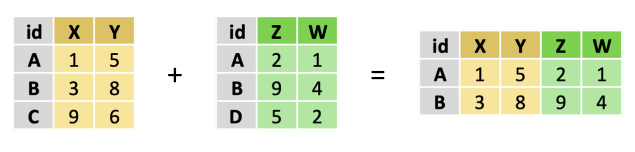

Jointure à gauche (*left join*)

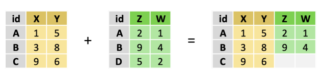

Jointure à droite (*right join*)

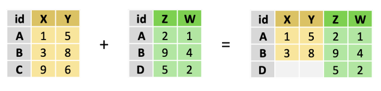

Jointure externe (*full join*)

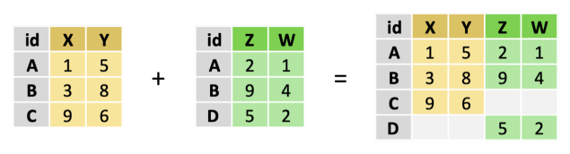

`full_join`

**Les lignes de chacune des tables abondent la fusion.**

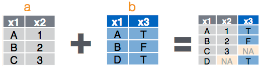

*Comportement d’un full_join*

`inner_join`

**Seules les lignes aux identifiants communs abondent la fusion.** Dans le cas de `inner_join(x, y)`, seules les lignes présentes à la fois dans `x` et `y` sont conservées (et si nécessaire dupliquées) dans la table résultat.

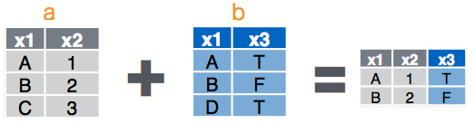

*Comportement d’un inner_join*

`left_join`

**Les lignes de la première table sont conservées et sont abondées par les lignes de la deuxième table qui partagent les mêmes identifiants.**

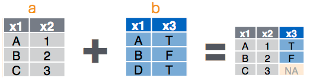

*Comportement d’un left_join*

`right_join`

**Les lignes de la seconde table sont conservées et sont abondées par les lignes de la première table qui partagent les mêmes identifiants.**

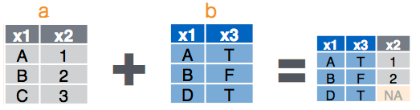

*Comportement d’un right_join*

`anti_join`

L’anti-jointure est une opération de jointure qui renvoie toutes les observations d’une table qui n’ont pas de correspondance dans une autre table.  
**Seules les lignes de la première table dont les variables identifiantes n’apparaissent pas dans la seconde table sont conservées.** `anti_join` est une jointure *filtrante*, c’est-à-dire qu’elle sélectionne certaines lignes de `a` sans ajouter les colonnes de `b`. Un `anti_join` ne conserve que les lignes de `a` absentes de `b`.

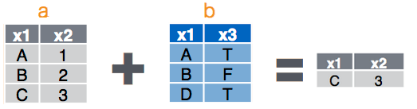

*Comportement d’un anti_join*

```r
# Trouver les siret qui ont disparu
siret_disparus_2021 <- anti_join(abatga_siret_2020, abatga_siret_2021,
                                 join_by(siret))

siret_disparus_2022 <- anti_join(abatga_siret_2021, abatga_siret_2022,
                                 join_by(siret))

siret_disparus_2023 <- anti_join(abatga_siret_2022, abatga_siret_2023,
                                 join_by(siret))

siret_disparus_2024 <- anti_join(abatga_siret_2023, abatga_siret_2024,
                                 join_by(siret))
```

`semi_join`

**Seules les lignes de la première table dont les variables identifiantes apparaissent dans la seconde table sont conservées.**

`semi_join` est une jointure *filtrante*, c’est-à-dire qu’elle sélectionne certaines lignes de `a` sans ajouter les colonnes de `b`.

Ainsi, `semi_join` ne conservera que les lignes de `a` pour lesquelles une ligne de `b` existe également, et supprimera les autres. Seulement les colonnes de `a` seront incluses dans le résultat.

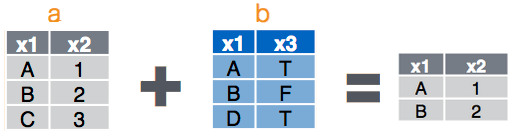

*Comportement d’un semi_join*

On peut utiliser l’argument `suffix` de `..._join`, pour indiquer les suffixes à ajouter aux colonnes communes.

Différencier les variables partageant le même nom dans les deux tables

Lorsque des variables ont le même nom dans deux tables différentes mais ne sont pas des variables de jointure, on peut choisir le suffixe à leur donner dans la table résultat avec l’argument suffix.  
Il s’écrit sous la forme :  
suffix = c(“_tab1”, “_tab2”)

```r
flights_ex |>
  left_join(
    airports_ex,
    join_by(dest == faa),
    suffix = c("_depart", "_arrivee")
  )
```

Remarque : toutes les variables ne seront pas suffixées selon leur table d’origine, seulement celles possédant le même nom dans les deux tables.

# 8 Manipuler du texte

Mettre x en majuscules : `toupper(x)` ou `str_to_upper(x)` du package `stringr`.  
Mettre x en minuscules : `tolower(x)` ou `str_to_lower(x)` du package `stringr`.

## 8.1 Concaténer des chaînes de caractères

Pour concaténer des chaînes de caractères, on peut le faire avec la fonction `paste`.

Par défaut, `paste` concatène en ajoutant un espace entre les différentes chaînes. On peut spécifier un autre séparateur avec son argument `sep` :

```r
# Par exemple, si on veut concaténer l'adresse et la ville
paste(df$adresse, df$ville, sep = " - ")
```

La variante `paste0` concatène sans mettre de séparateur.

`paste` et `paste0` sont des fonctions R de base. L’équivalent pour le package `stringr` se nomme `str_c`.

## 8.2 Extraire des éléments d’une chaîne de caractères avec `substr()`

La fonction `substr()` permet d’extraire une sous-chaine à partir d’une chaine de caractères.

`substr(x, start, stop)` extrait une sous-chaîne de caractères.

Le premier argument est la chaine de caractères,  
le deuxième correspond à la position de départ du caractère de la chaîne  
et le troisième à la position d’arrivée du caractère auquel ou souhaite s’arrêter (la fin de la sous-chaine que l’on souhaite extraire).

```r
depcom <- "44001"

dep <- substr(depcom, 1, 2)
# La sous-chaine débute au 1er caractère et se finit au 2e
# Ainsi on extrait "44"

# Filtrer les enregistrements de la région Pays de la Loire
bio_pdl <- bio |>
  filter(substr(codecommuneinsee, 1, 2) %in% c('44', '49', '53', '72', '85'))

# Créer une variable dep pour département
bio_pdl <- bio |>
  filter(substr(codecommuneinsee, 1, 2) %in% c('44', '49', '53', '72', '85')) |>
  mutate(dep = substr(codecommuneinsee, 1, 2))

# Extraire une chaîne de caractères avec `substr`
laits_mensuel_2 <- laits_mensuel_1 |>
  mutate(dep_etab = substr(sircodpost, 1, 2),
         dep_prod = substr(dep, 2, 3))
```

## 8.3 Extraire une chaîne de caractères avec `str_sub()`

Parfois on a besoin de manipuler le contenu du texte d’une variable de type chaîne de caractères : combiner, rechercher, remplacer…

Le package `stringr` propose des fonctions de manipulation de chaînes de caractère. `stringr` est une interface simplifiée aux fonctions d’un autre package, `stringi`.

Extraire une chaîne de caractères avec `str_sub()`

`str_sub()` prend 3 arguments : une chaîne de caractère, une position de début, une position de fin. Les positions peuvent être positives, et dans ce cas, on compte à partir de la gauche, ou négatives, et dans ce cas on compte à partir de la droite.

```r
library(dplyr)
library(stringr)
a <- data.frame(x = c(" libeatg", "delivo y"))

b <- mutate(a, pos3a4 = str_sub(string = x, start = 3, end = 4),
               pos3a2avtlafin = str_sub(string = x, start = 3, end = -2))
```

`str_sub()` peut être utilisé pour remplacer un caractère

```r
str_sub(a$x, start = 6, end = 9) <- "rer"

a$x
```

Il est possible de rajouter le suffixe `_all` à la fonctions `str_sub`. Le “_all” permet de l’appliquer à toutes les occurrences et pas seulement à la première.

Si on souhaite réaliser ce genre d’opération dans le cadre d’un `mutate`, il faut utiliser une fonction dite “pipe-operator-friendly”, par exemple `stri_sub_replace()` du package `stringi`

```r
# install.packages("stringi")
library(stringi)

a <- data.frame(x = c(" libeatg", "delivo y"))

b <- mutate(a, y = stri_sub_replace(str = x, from = 6, to = 9, value = "rer"))
```

https://stringr.tidyverse.org/  
https://stringi.gagolewski.com/

## 8.4 Détecter des motifs

`str_detect` du package `stringr` permet de détecter la présence d’un motif parmi les élements d’un vecteur. Par exemple, si on souhaite identifier toutes les adresses contenant “Libération” :

```r
str_detect(df$adresse, "Libération")
```

`str_detect` renvoie un vecteur de valeurs logiques et peut donc être utilisée, par exemple, avec le verbe `filter` de `dplyr` pour extraire des sous-populations.

```r
# Filtrer les lignes où sous_groupe_de_productions contient "Toutes"
bio_vege2_pdl_reg_total <- bio_vege2_pdl_reg |>
  filter(str_detect(sous_groupe_de_productions, "Toutes"))
```

## 8.5 Remplacer des motifs

Pour remplacer un motif dans une chaîne de caractères, on peut utiliser `str_replace` du package `stringr`.  
str_replace(x, motif, remplacement) remplace la première occurrence uniquement.

Pour remplacer toutes les occurrences d’un motif par un autre, il convient d’utiliser la fonction `str_replace_all` du package `stringr`.

Par exemple, on peut remplacer les occurrence de “Mr” par “M.” dans la variable `nom` :

```r
str_replace_all(df$nom, "Mr", "M.")
```

On peut également spécifier plusieurs remplacements en une seule fois :

```r
str_replace_all(
    df$adresse,
    c("avenue" = "Avenue", "ave" = "Avenue", "rue" = "Rue")
)
```

La fonction `stri_trans_general(x, "Latin-ASCII")` du package `stringi` permet d’enlever les accents dans une chaîne de caractères.

```r
library(stringi)

# Remplacer les accents dans les noms des groupes de production
# stri_trans_general(x, "Latin-ASCII") :
# Cette fonction de stringi transforme les caractères accentués
# en leurs équivalents non accentués. Par exemple, "Chèvres" devient "Chevres".
bio_anim2_pdl_an <- bio_anim2_pdl_an |>
  mutate(groupe_de_productions = stri_trans_general(groupe_de_productions, "Latin-ASCII"))
```

## 8.6 Ajouter un préfixe à un nom de variable

```r
# ajout prefixe annee pour Total
vol_2022 <- vol_2022 |>
  rename(total_nombre = paste0("x2022_", total_nombre),
         total_poids = paste0("x2022_", total_poids))

# autre méthode
vol_2022 <- vol_2022 |>
  rename_with(.cols = c(total_nombre,total_poids), function(x){paste0("x2022_", x)})

# On peut simplifier le code en utilisant une fonction anonyme plus courte avec `\(x)`.
# Le `x` est une variable qui représente chaque élément des colonnes spécifiées.
vol_2022 <- vol_2022 |>
  rename_with(.cols = c(total_nombre,total_poids), \(x) paste0("x2022_", x))
```

R fournit maintenant une notation abrégée pour créer des fonctions,  
par exemple (x) x + 1 est interprété comme function(x) x + 1.

## 8.7 Ajouter un suffixe à un nom de variable

```r
library(openxlsx2)

# ajout suffixe annee aux variables
bio_2023 <- read_xlsx(file = path(chemin, fichier_2023),
                      sheet = "Feuil1") |>
  as_tibble(.name_repair = make_clean_names) |>
  rename_with(.cols = c(nombre_dassocies_gaec, quantite_declaree),
              function(x) {paste0(x, "_2023")})
```

```r
# Renommage des colonnes : Les colonnes sont renommées avec un suffixe correspondant à l'année.
# ajout suffixe année aux noms de colonnes sauf pour la première colonne (indicateur)
montants_pdl_2020_p1_p2 <- montants_pdl_2020_p1_p2 |>
  rename_with(\(x) paste0(x, "_", 2020), -indicateur)
```

## 8.8 Supprimer un préfixe à un nom de variable pour l’ensemble des noms de colonnes

La fonction `colnames()` renvoie la liste des noms de colonnes d’un tableau.

colnames(df) <- … : Cette partie de la commande assigne les nouveaux noms de colonnes dans df

La fonction `gsub()` remplace toutes les occurrences d’un motif dans une chaîne de caractères. Pour supprimer un préfixe, on peut spécifier le motif du préfixe à supprimer et le remplacer par une chaîne vide.

```r
# enlever le préfixe prod_ de tous les noms de colonnes dans le dataframe viande_volaille_annee_pdl
colnames(viande_volaille_annee_pdl) <- gsub("prod_", "", colnames(viande_volaille_annee_pdl))

# ou bien
# names(viande_volaille_annee_pdl) <- gsub("prod_", "", names(viande_volaille_annee_pdl))
```

```r
# Pour enlever le préfixe « surf_ ».
# On modifie le libellé espece avec la fonction gsub ou avec la fonction str_remove (c'est équivalent)
balsa_dep <- balsa_dep |>
  mutate(espece = gsub("surf_", "", espece))
balsa_reg <- balsa_reg |>
  mutate(espece = str_remove(espece, "surf_"))
```

```r
# Renommer des colonnes en supprimant un préfixe
# rename_with(\(x) str_replace(x, "nb_tetes_", ""), starts_with("nb_tetes"))
# rename_with : renommer les colonnes en utilisant une fonction de transformation anonyme `\(x)`
# rename_with() renames columns using a function.
# rename_with(.data, .fn, .cols = everything(), ...)
# str_replace(x, "nb_tetes_", "") : remplacer le préfixe "nb_tetes_"
# par une chaîne vide dans les noms de colonnes.
# starts_with("nb_tetes") : s'applique uniquement aux colonnes dont les noms commencent par "nb_tetes".
bio_anim_nb_tetes_pdl_an <- bio_anim2_pdl_an_export |>
  filter(echelle_geographique == "Régional") |>
  select(echelle_geographique, territoire, type_de_production, groupe_de_productions, starts_with("nb_tetes")) |>
  # Renommer les colonnes en supprimant le préfixe "nb_tetes_" avant l'année
  rename_with(\(x) str_replace(x, "nb_tetes_", "an_"),
    .cols = starts_with("nb_tetes")
  ) |>
  # Ajouter une nouvelle colonne indicateur avec la valeur "nb_tetes"
  mutate(indicateur = "nb_tetes", .after = "groupe_de_productions")
```

## 8.9 Supprimer un suffixe à un nom de variable pour l’ensemble des noms de colonnes

La fonction `colnames()` renvoie la liste des noms de colonnes d’un tableau.

colnames(df) <- … : Cette partie de la commande assigne les nouveaux noms de colonnes dans df

La fonction `gsub()` remplace toutes les occurrences d’un motif dans une chaîne de caractères. Pour supprimer un suffixe, on peut spécifier le motif du suffixe à supprimer et le remplacer par une chaîne vide.

```r
# enlever le suffixe _valeur_en_k de tous les noms de colonnes dans le dataframe produits
colnames(produits) <- gsub("_valeur_en_k", "", colnames(produits))

# ou bien
# names(produits) <- gsub("_valeur_en_k", "", names(produits))
```

## 8.10 Remplacer partout les points par des virgules, en vue d’un export vers excel

```r
library(stringr) # pour str_replace

# remplacement point par virgule
lait_vache_reg_dep_2021_donnees_secret_2 <- lait_vache_reg_dep_2021_donnees_secret_1 |>
  mutate(across(
    .cols = everything(),
    \(x) str_replace(x, "[.]", ","))
```

## 8.11 Modificateurs de motifs

Par défaut, les motifs passés aux fonctions comme `str_detect` ou `str_replace` sont des expressions régulières classiques.

Il faut donc spécifier que le point est bien un point avec `fixed` :

```r
str_count(df$nom, fixed("."))
```

On peut aussi modifier le comportement des expressions régulières à l’aide de la fonction `regex`. On peut ainsi rendre les motifs insensibles à la casse avec `ignore_case` :

```r
str_detect(df$nom, regex("mme", ignore_case = TRUE))
```

## 8.12 `str_pad` pour ajouter des caractères en début ou en fin de chaîne

La fonction `str_pad` remplit une chaîne de caractères avec des espaces (par défaut) ou une valeur choisie (argument pad) à une largeur fixe, de sorte que str_length(str_pad(x, n)) soit toujours supérieur ou égal à n.  
Il est possible de remplir avant et / ou après la chaîne de caractères existant (avec l’argument `side`).

str_pad(x, width = longueur_format, side = ‘’left’’, pad = caractère_a_ajouter).

```r
# exemple pour siren
str_pad(x, width = 5, side = "left", pad = "0")
```

```r
# pour formater le mois sur 2 positions en ajoutant un zéro devant si nécessaire ----

# la fonction str_pad() (du package stringr) est utilisée pour ajouter un zéro à gauche du mois si nécessaire,
# afin d'obtenir une représentation sur 2 positions.
# ajoute un zéro à gauche du mois si le mois est un chiffre unique.
# pad pour “remplissage”
# str_pad(string, width, side = "left", pad = " ")
# string est la chaîne de caractères à laquelle on ajoute du padding.
# width est la largeur totale souhaitée de la chaîne de caractères après l’ajout du padding.
# side indique de quel côté ajouter le padding. Les options sont "left", "right", ou "both".
# Par défaut, le padding est ajouté à gauche.
# pad est le caractère à utiliser pour le padding. Par défaut, c’est un espace.

# on utilise la fonction sprintf (fonction de base en R) qui permet de formater une chaîne de caractères
# le format "%02d" est utilisé pour formater un nombre en une chaîne de caractères de deux chiffres.
# % : indique le début d’un spécificateur de format.
# 0 : indique que les espaces vides doivent être remplis avec des zéros.
# 0 : indique que les nombres doivent être précédés d'un zéro si nécessaire
# pour atteindre la longueur totale spécifiée.
# 2 : indique la longueur totale du résultat (la largeur minimale du champ de sortie)
# Si le nombre à formater est plus court que cette largeur,
# des zéros seront ajoutés au début pour atteindre la largeur spécifiée.
# d : indique que le type de données à formater est un nombre entier (décimal).

# La fonction formatC (base) est utilisée pour formater une valeur numérique en une chaîne de caractères
# avec une largeur et un format spécifiés.
# width = 2 : Cela spécifie que la valeur formatée doit avoir une largeur de deux caractères,
# y compris les zéros au début, si nécessaire.
# flag = 0 : Cela spécifie que les zéros en tête doivent être inclus dans la valeur formatée.
itavi <- itavi |>
  mutate(annee = year(an_mois_date),
         mois = str_pad(month(an_mois_date), width = 2, pad = "0"),
         mois_b = sprintf("%02d", month(an_mois_date)),
         # fonction strftime() du package lubridate
         mois_c = strftime(an_mois_date, "%m"),
         # format() est une fonction de base, souvent utilisée pour formater des dates.
         mois_d = format(as.Date(an_mois_date), "%m"),
         mois_e = formatC(month(an_mois_date), width = 2, flag = 0),
         # extrait le mois de la variable an_mois_date
         # et le convertit en un nom de mois complet (par exemple, "janvier" pour le mois 1).
         mois_car = format(an_mois_date, "%B"),
         an_mois = paste0(annee, "_", mois))

str(itavi)
```

## 8.13 Obtenir la longueur d’une chaîne de caractères avec `str_length()` :

La fonction `str_length()` du package `stringr` permet de connaître le nombre de caractères dans une chaîne de caractères.

```r
library(stringr)

str_length("abc")
```

## 8.14 Utiliser les expressions régulières

Une expression régulière (ou regex) est une chaîne de caractères qui décrit, selon une syntaxe précise, un ensemble de chaînes de caractères possibles.  
Les **expressions régulières** permettent la détection de motifs (patterns) sur des chaînes de caractères. Cette recherche textuelle sur motif (`pattern`) consiste à décrire ce qu’on cherche plutôt que comment chercher.

Exemple : Un nombre suivi d’une virgule se dit `\\d+,`

```
- la séquence `\\d` représente un chiffre quelconque
- le `+`’ signifie que ce qui précède (un chiffre) peut être répété
- la `,` signifie bien qu’on cherche à trouver une virgule.
```

Note : il convient de redoubler les `\` car ils sont interprétés à la lecture de la chaîne (comme pour les chemins windows).

Une expression régulière - également appelée `regex` (regular expression) - correspond à une chaîne de caratère décrivant, selon une syntaxe précise, un ensemble de chaînes de caractères possibles correspondant à cette même syntaxe.

Les expressions régulières sont représentées par un ensemble de symboles constituant le motif à rechercher dans des chaînes de caractères.

Afin de détecter la présence d’un motif dans un string, il convient d’utiliser la fonction `str_detect` du package `stringr`. Celle-ci retourne `TRUE` si un élément du texte sur lequel la fonction est appliquée correspond au motif indiqué.

```r
a <- data.frame(txt = c("vélo", "train", "voilier", "bus", "avion", "tram", "trottinette"))

b <- mutate(a, tr_au_debut = str_detect(string = txt, pattern = "^tr"))

b

filter(b, tr_au_debut)
# $ permet de s’assurer qu’on ne détecte que les noms se terminant par “n”,
# et pas ceux contenant “n” à un autre endroit.
filter(a, str_detect(string = txt, pattern = "n$"))


# \\d+ est une expression régulière qui correspond à une séquence de un ou plusieurs chiffres consécutifs
# \\d : Correspond à un chiffre (0-9).
# + : Indique que l'élément précédent doit apparaître une ou plusieurs fois.
```

```r
# pour récupérer les codes de département et de région
# str_extract() : fonction pour extraire une partie d'une chaîne de caractères.

# \\d{2} : recherche deux chiffres consécutifs.
# \\d : Il s'agit d'un caractère spécial qui représente un chiffre (decimal) dans les expressions régulières.
# La double barre oblique (\\) est nécessaire pour échapper le caractère spécial
# et l'interpréter comme un seul caractère correspondant à un chiffre.
# \\ est utilisé comme caractère d'échappement pour s'assurer que le caractère qui suit (d dans ce cas)
# est interprété comme un motif spécial de regex plutôt que comme un caractère littéral.
# \\d : C’est un métacaractère qui correspond à n’importe quel chiffre, équivalent à [0-9].
# \d dans le langage des expressions régulières est le métacaractère correspondant à un chiffre.
# {2} : quantificateur spécifiant la répétition exacte du précédent élément : doit se répéter exactement deux fois

# [0-9]+ : cette expression trouvera les chiffres présents dans la chaîne de caractères.
# [0-9]+ : cette expression trouvera une ou plusieurs occurrences de chiffres.
# Le caractère + indique que l'on cherche une ou plusieurs occurrences des chiffres précédents.

# Pour extraire les chiffres qui se trouvent entre parenthèses :
# (?<=\\()\\d+(?=\\)) signifie trouver une séquence de chiffres (\\d+)
# qui est précédée par une parenthèse ouvrante (?<=\\()
# et suivie par une parenthèse fermante (?=\\))”
# (?<=motif): lookbehind (rétrovision) positif, cela signifie que la correspondance doit être précédée par "motif".
# Elle recherche une position juste après "motif".
# vérifie que la chaîne de caractères recherchée est précédée d'une autre chaîne de caractères spécifique,
# sans inclure cette chaîne de caractères dans le résultat de la recherche.
# (?=motif): lookahead (antériorité) positif, cela signifie que la correspondance doit être suivie par "motif".
# Elle vérifie si le motif suivant est "motif" sans inclure ce motif dans le résultat.
# vérifie que la chaîne de caractères recherchée est suivie d'une autre chaîne de caractères spécifique,
# sans inclure cette chaîne de caractères dans le résultat de la recherche.

# pb pour Corse-du-Sud (2A) et Haute-Corse (2B)
# problème avec les codes de département 2A et 2B car ils contiennent des lettres.
# \\d+[A-Z]? : pour extraire une séquence composée d'un ou plusieurs chiffres
# suivis facultativement d'une lettre majuscule.
# \\d+" : représente un ou plusieurs chiffres.
# [A-Z]? : représente une lettre majuscule de A à Z de façon facultative.
# Le point d'interrogation "?" signifie que la lettre majuscule est optionnelle et peut apparaître 0 ou 1 fois.

# On cherche tout ce qu'il y a entre "(" et ")".
# \\w+ correspond à une séquence de caractères alphanumériques (chiffres et lettres).
# \\w est utilisé pour correspondre à un caractère alphanumérique (word), c’est-à-dire un chiffre ou une lettre

# \\d{1,2}[A-B]? : accepte les séquences qui ont un ou deux chiffres suivis éventuellement par 'A' ou 'B'.
# {1,2} : Ce quantificateur spécifie que le motif précédent doit apparaître au moins 1 fois et jusqu'à 2 fois.
# Cela signifie que l'expression peut capturer des nombres à un ou deux chiffres.
# [A-B] : n'importe quel caractère unique dans l'intervalle spécifié, ici de 'A' à 'B'.
# Cela signifie qu'elle peut capturer soit 'A', soit 'B'.
# ? : Ce quantificateur rend le motif précédent facultatif.
# Cela signifie que l'expression [A-B] peut apparaître 0 ou 1 fois.
nb_etp_2 <- nb_etp_1 |>
  mutate(reg = str_extract(region, "\\d{2}"),
         reg_b = str_extract(region, "[0-9]+"),
         reg_c = str_extract(region, "(?<=\\()\\d+(?=\\))"),
         dep = str_extract(departement, "\\d+[A-Z]?"),
         dep_b = str_extract(departement, "(?<=\\()\\w+(?=\\))"),
         dep_c = str_extract(departement, "(?<=\\()\\d{1,2}[A-B]?"),
         .before = 1)

sort(unique(nb_etp_2$reg))
sort(unique(nb_etp_2$dep))
```

```r
# supprimer le préfixe (01_, 02_) des modalités dans la variable eff_tranche
# "^\\d{2}_" : motif cherché dans chaque élément de eff_tranche. Le motif est une expression régulière.
#   ^ : début de la chaîne.
# \\d : n’importe quel chiffre (équivalent à [0-9]).
# {2} : exactement à deux occurrences du caractère précédent (dans ce cas, \\d).
# _ : caractère de soulignement.
# "" : C’est la chaîne de remplacement. Dans ce cas, on remplace le motif trouvé par une chaîne vide,
# ce qui a pour effet de supprimer le motif de la chaîne.

iaa_vol_regroup <- iaa_vol_regroup |>
  mutate(eff_tranche = str_replace(eff_tranche, "^\\d{2}_", ""))
```

```r
# ouverture fichier janvier
# str_extract() : fonction pour extraire une partie d'une chaîne de caractères.
# Dans ce cas, elle extrait le mois du nom de chaque fichier.
# "(?<=_2025_)\\d{2}" : cette expression signifie “trouver exactement deux chiffres (\\d{2}) après _2025_”.
# \\d{2} : recherche deux chiffres consécutifs.
# \\d : Il s'agit d'un caractère spécial qui représente un chiffre (decimal) dans les expressions régulières.
# La double barre oblique (\\) est nécessaire pour échapper le caractère spécial
# et l'interpréter comme un seul caractère correspondant à un chiffre.
# \\ est utilisé comme caractère d'échappement pour s'assurer que le caractère qui suit (d dans ce cas)
# est interprété comme un motif spécial de regex plutôt que comme un caractère littéral.
# \\d : C’est un métacaractère qui correspond à n’importe quel chiffre, équivalent à [0-9].
# \d dans le langage des expressions régulières est le métacaractère correspondant à un chiffre.
# {2} : quantificateur qui spécifie la répétition exacte du précédent élément (exactement deux fois).
# (?<=_2025_): lookbehind (rétrovision) positif, signifiant que la correspondance doit être précédée par "_2025_".
# Elle recherche une position juste après le motif _2025_.
# vérifie que la chaîne de caractères recherchée est précédée d'une autre chaîne de caractères spécifique,
# sans inclure cette chaîne de caractères dans le résultat de la recherche.
# "(?<=2025_)[0-9]{2}" : cette expression trouvera deux chiffres ([0-9]{2}) après 2025_.
# "(?<=2025_)[0-9]+(?=_)" : cette expression trouvera une ou plusieurs occurrences de chiffres ([0-9]+)
# après 2025_ jusqu'au prochain (_).
# Le caractère + indique que l'on cherche une ou plusieurs occurrences des chiffres précédents.
# (?=_): est un lookahead (antériorité) positif, cela signifie que la correspondance doit être suivie par "_".
# Elle vérifie si le motif suivant est "_" sans inclure ce motif dans le résultat.
# vérifie que la chaîne de caractères recherchée est suivie d'une autre chaîne de caractères spécifique,
# sans inclure cette chaîne de caractères dans le résultat de la recherche.
eff_bovins_2024 <- read_csv2(file = path(chemin_bdni, eff_an_2025, fichier_01_2025)) |>
  mutate(mois = str_extract(fichier_01_2025, "(?<=_2025_)\\d{2}"),
         mois_b = str_extract(fichier_01_2025, "(?<=2025_)[0-9]{2}"),
         mois_c = str_extract(fichier_01_2025, "(?<=2025_)[0-9]+"),
         mois_d = str_extract(fichier_01_2025, "(?<=2025_)[0-9]+(?=_)"))
```

Les fonctions de `stringr` étant prévues pour fonctionner avec des expressions régulières, certains caractères n’auront pas le sens habituel dans la chaîne indiquant le motif à rechercher. Par exemple, le `.` ne sera pas un point mais le symbole représentant “n’importe quel caractère”.

```r
# Exclusion des colonnes dont les noms contiennent "ss_groupe_prod".
# Renommage des colonnes pour ne garder que le format an_aaaa,
# où \\1 est l'année capturée par le groupe de capture (\\d{4}).
# (\\d{4}) : Capture un groupe de quatre chiffres (représentant l'année)
# et les place dans un groupe de capture.
# Les parenthèses () définissent le groupe de capture,
# et \\d{4} signifie "quatre chiffres".
# La chaîne de remplacement "an_\\1"
# utilise \\1 pour insérer le contenu du premier groupe de capture
# (les quatre chiffres représentant l'année) dans le nouveau nom de la colonne.
# an_ : Préfixe littéral pour le nouveau nom de la colonne.
# \\1 : Référence au premier groupe de capture, qui contient l'année capturée par (\\d{4}).
bio_vege_groupe_prod_surf_tot_bio_dep_pdl_part_reg <- bio_vege_dep_pdl_part_reg_export |>
  filter(str_starts(sous_groupe_de_productions, "toutes")) |>
  select(
    echelle_geographique, territoire,
    type_de_production, groupe_de_productions, sous_groupe_de_productions,
    rang_groupe_prod_surf_tot_bio_an_2023,
    starts_with("surf_tot_bio_")
  ) |>
  select(-matches("ss_groupe_prod")) |>
  rename_with(
      \(x) str_replace(
      x,
      "surf_tot_bio_an_(\\d{4})_group_prod_part_reg",
      "an_\\1"
    ),
    .cols = starts_with("surf_tot_bio_")
  ) |>
  mutate(indicateur = "surf_tot_bio", .after = "groupe_de_productions")
```